# Capstone Project Data Science

## Project Title: Time series Analysis :JetRail Development and Investment Prediction

#### Problem Statement

" Unicorn Investors wants to make an investment in a new form of transportation - JetRail. JetRail uses Jet propulsion technology and Foursquare Location Data (API) to run rails and move people at a high speed! The investment would only make sense, if they can get more than 1 Million monthly users with in next 18 months. In order to help Unicorn Ventures in their decision, you need to forecast the traffic on JetRail for the next 7 months. You are provided with traffic data of JetRail since inception in the test file."

#### Hypothesis Generation

We will start with the first step, i.e. Hypothesis Generation. Hypothesis Generation is the process of listing out all the possible factors that can affect the outcome.

Hypothesis generation is done before having a look at the data in order to avoid any bias that may result after the observation.

1) Hypothesis Generation Hypothesis generation helps us to point out the factors which might affect our dependent variable. Below are some of the hypotheses which I think can affect the passenger count(dependent variable for this time series problem) on the JetRail:

##### There will be an increase in the traffic as the years pass by.

Explanation - Population has a general upward trend with time, so I can expect more people to travel by JetRail. Also, generally companies expand their businesses over time leading to more customers travelling through JetRail.

##### The traffic will be high from May to October.

Explanation - Tourist visits generally increases during this time perion.

##### Traffic on weekdays will be more as compared to weekends/holidays.

Explanation - People will go to office on weekdays and hence the traffic will be more

##### Traffic during the peak hours will be high.

Explanation - People will travel to work, college.

## Getting the system ready and Loading Data

After building hypothesis we will try to validate our hypothesis result by taking first step

```python
import pandas as pd
import numpy as np          # For mathematical calculations
import matplotlib.pyplot as plt  # For plotting graphs
from datetime import datetime    # To access datetime
from pandas import Series        # To work on series
%matplotlib inline
import warnings                   # To ignore the warnings
warnings.filterwarnings("ignore")
```

```python
train=pd.read_csv("Train_SU63ISt.csv")
test=pd.read_csv("Test_0qrQsBZ.csv")
```

```python
train_original=train.copy()
test_original=test.copy()
```

Data loaded and original copy is saved to another dateframe so as to preserve the datasets structure

## Dataset Structure and Content

lets dive deep into data know its structure and what does dataset trying to convey

```python
train.columns,test.columns
```

```
(Index(['ID', 'Datetime', 'Count'], dtype='object'),
 Index(['ID', 'Datetime'], dtype='object'))
```

Three Features are availaable namely ID ,Datetime ,and count .

by the way one thing to ne noticed is that there is only two features in column set of test file . we have to determine traffick count

```python
train.duplicated().sum()
```

```
0
```

```python
train.dtypes,test.dtypes
```

```
(ID           int64
 Datetime    object
 Count        int64
 dtype: object, ID           int64
 Datetime    object
 dtype: object)
```

here in train file two columns are nueric and one is object data i,e; string object we need convert to to datetime

```python
train.shape,test.shape
```

```
((18288, 3), (5112, 2))
```

Dateset size has been obtained !!!

# Feature Engineering

It involves Art of feature Engineering Feature selection feature Extraction

```python
train['Datetime'] = pd.to_datetime(train.Datetime,format='%d-%m-%Y %H:%M')
test['Datetime'] = pd.to_datetime(test.Datetime,format='%d-%m-%Y %H:%M')
test_original['Datetime'] = pd.to_datetime(test_original.Datetime,format='%d-%m-%Y %H:%M')
train_original['Datetime'] = pd.to_datetime(train_original.Datetime,format='%d-%m-%Y %H:%M')
```

We made some hypothesis for the effect of hour, day, month and year on the passenger count. So, let’s extract the year, month, day and hour from the Datetime to validate our hypothesis.

```python
for i in (train, test, test_original, train_original):
    i['year']=i.Datetime.dt.year
    i['month']=i.Datetime.dt.month
    i['day']=i.Datetime.dt.day
    i['Hour']=i.Datetime.dt.hour
```

We made a hypothesis for the traffic pattern on weekday and weekend as well. So, let’s make a weekend variable to visualize the impact of weekend on traffic.

We will first extract the day of week from Datetime and then based on the values we will assign whether the day is a weekend or not.

Values of 5 and 6 represents that the days are weekend.

```python
train['day of week']=train['Datetime'].dt.dayofweek
temp = train['Datetime']
temp
```

```
0       2012-08-25 00:00:00
1       2012-08-25 01:00:00
2       2012-08-25 02:00:00
3       2012-08-25 03:00:00
4       2012-08-25 04:00:00
5       2012-08-25 05:00:00
6       2012-08-25 06:00:00
7       2012-08-25 07:00:00
8       2012-08-25 08:00:00
9       2012-08-25 09:00:00
10      2012-08-25 10:00:00
11      2012-08-25 11:00:00
12      2012-08-25 12:00:00
13      2012-08-25 13:00:00
14      2012-08-25 14:00:00
```

[output cut: 47 more lines]

```python
def applyer(row):
    if row.dayofweek == 5 or row.dayofweek == 6:
        return 1
    else:
        return 0

temp2 = train['Datetime'].apply(applyer)
train['weekend']=temp2
```

```python
print ('letss look at the time series')
```

```
letss look at the time series
```

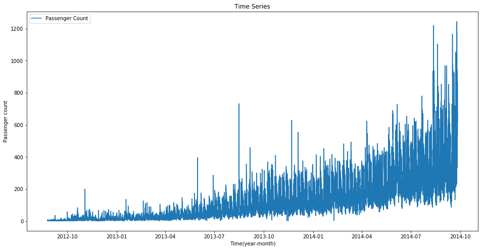

```python
train.index = train['Datetime'] # indexing the Datetime to get the time period on the x-axis.
df=train.drop('ID',1)           # drop ID variable to get only the Datetime on x-axis.
ts = df['Count']
plt.figure(figsize=(16,8))
plt.plot(ts, label='Passenger Count')
plt.title('Time Series')
plt.xlabel("Time(year-month)")
plt.ylabel("Passenger count")
plt.legend(loc='best')
```

Here we can infer that there is an increasing trend in the series, i.e., the number of count is increasing with respect to time. We can also see that at certain points there is a sudden increase in the number of counts. The possible reason behind this could be that on particular day, due to some event the traffic was high.

We will work on the train file for all the analysis and will use the test file for forecasting.

## Explorotary Data Analysis

Let's Reacall our hyporthesis made ,whih can affect our outcome or rsult 1.year passess by 2.month of the year 3.day of the month 4.Hour in a day which has peak load 5.day of week: either weekdays or weekends

```python
train
```

| Datetime | ID | Datetime | Count | year | month | day | Hour | day of week | weekend |
| --- | --- | --- | --- | --- | --- | --- | --- | --- | --- |
| 2012-08-25 00:00:00 | 0 | 2012-08-25 00:00:00 | 8 | 2012 | 8 | 25 | 0 | 5 | 1 |
| 2012-08-25 01:00:00 | 1 | 2012-08-25 01:00:00 | 2 | 2012 | 8 | 25 | 1 | 5 | 1 |
| 2012-08-25 02:00:00 | 2 | 2012-08-25 02:00:00 | 6 | 2012 | 8 | 25 | 2 | 5 | 1 |
| 2012-08-25 03:00:00 | 3 | 2012-08-25 03:00:00 | 2 | 2012 | 8 | 25 | 3 | 5 | 1 |
| 2012-08-25 04:00:00 | 4 | 2012-08-25 04:00:00 | 2 | 2012 | 8 | 25 | 4 | 5 | 1 |
| 2012-08-25 05:00:00 | 5 | 2012-08-25 05:00:00 | 2 | 2012 | 8 | 25 | 5 | 5 | 1 |
| 2012-08-25 06:00:00 | 6 | 2012-08-25 06:00:00 | 2 | 2012 | 8 | 25 | 6 | 5 | 1 |
| 2012-08-25 07:00:00 | 7 | 2012-08-25 07:00:00 | 2 | 2012 | 8 | 25 | 7 | 5 | 1 |
| 2012-08-25 08:00:00 | 8 | 2012-08-25 08:00:00 | 6 | 2012 | 8 | 25 | 8 | 5 | 1 |
| 2012-08-25 09:00:00 | 9 | 2012-08-25 09:00:00 | 2 | 2012 | 8 | 25 | 9 | 5 | 1 |
| 2012-08-25 10:00:00 | 10 | 2012-08-25 10:00:00 | 2 | 2012 | 8 | 25 | 10 | 5 | 1 |
| 2012-08-25 11:00:00 | 11 | 2012-08-25 11:00:00 | 6 | 2012 | 8 | 25 | 11 | 5 | 1 |
| 2012-08-25 12:00:00 | 12 | 2012-08-25 12:00:00 | 4 | 2012 | 8 | 25 | 12 | 5 | 1 |
| 2012-08-25 13:00:00 | 13 | 2012-08-25 13:00:00 | 2 | 2012 | 8 | 25 | 13 | 5 | 1 |
| 2012-08-25 14:00:00 | 14 | 2012-08-25 14:00:00 | 6 | 2012 | 8 | 25 | 14 | 5 | 1 |
| 2012-08-25 15:00:00 | 15 | 2012-08-25 15:00:00 | 2 | 2012 | 8 | 25 | 15 | 5 | 1 |
| 2012-08-25 16:00:00 | 16 | 2012-08-25 16:00:00 | 2 | 2012 | 8 | 25 | 16 | 5 | 1 |
| 2012-08-25 17:00:00 | 17 | 2012-08-25 17:00:00 | 2 | 2012 | 8 | 25 | 17 | 5 | 1 |
| 2012-08-25 18:00:00 | 18 | 2012-08-25 18:00:00 | 2 | 2012 | 8 | 25 | 18 | 5 | 1 |
| 2012-08-25 19:00:00 | 19 | 2012-08-25 19:00:00 | 2 | 2012 | 8 | 25 | 19 | 5 | 1 |
| 2012-08-25 20:00:00 | 20 | 2012-08-25 20:00:00 | 2 | 2012 | 8 | 25 | 20 | 5 | 1 |
| 2012-08-25 21:00:00 | 21 | 2012-08-25 21:00:00 | 6 | 2012 | 8 | 25 | 21 | 5 | 1 |
| 2012-08-25 22:00:00 | 22 | 2012-08-25 22:00:00 | 2 | 2012 | 8 | 25 | 22 | 5 | 1 |
| 2012-08-25 23:00:00 | 23 | 2012-08-25 23:00:00 | 2 | 2012 | 8 | 25 | 23 | 5 | 1 |
| 2012-08-26 00:00:00 | 24 | 2012-08-26 00:00:00 | 4 | 2012 | 8 | 26 | 0 | 6 | 1 |
| 2012-08-26 01:00:00 | 25 | 2012-08-26 01:00:00 | 6 | 2012 | 8 | 26 | 1 | 6 | 1 |
| 2012-08-26 02:00:00 | 26 | 2012-08-26 02:00:00 | 2 | 2012 | 8 | 26 | 2 | 6 | 1 |
| 2012-08-26 03:00:00 | 27 | 2012-08-26 03:00:00 | 4 | 2012 | 8 | 26 | 3 | 6 | 1 |
| 2012-08-26 04:00:00 | 28 | 2012-08-26 04:00:00 | 2 | 2012 | 8 | 26 | 4 | 6 | 1 |
| 2012-08-26 05:00:00 | 29 | 2012-08-26 05:00:00 | 2 | 2012 | 8 | 26 | 5 | 6 | 1 |
| ... | ... | ... | ... | ... | ... | ... | ... | ... | ... |
| 2014-09-24 18:00:00 | 18258 | 2014-09-24 18:00:00 | 966 | 2014 | 9 | 24 | 18 | 2 | 0 |
| 2014-09-24 19:00:00 | 18259 | 2014-09-24 19:00:00 | 1178 | 2014 | 9 | 24 | 19 | 2 | 0 |
| 2014-09-24 20:00:00 | 18260 | 2014-09-24 20:00:00 | 1008 | 2014 | 9 | 24 | 20 | 2 | 0 |
| 2014-09-24 21:00:00 | 18261 | 2014-09-24 21:00:00 | 936 | 2014 | 9 | 24 | 21 | 2 | 0 |
| 2014-09-24 22:00:00 | 18262 | 2014-09-24 22:00:00 | 848 | 2014 | 9 | 24 | 22 | 2 | 0 |
| 2014-09-24 23:00:00 | 18263 | 2014-09-24 23:00:00 | 942 | 2014 | 9 | 24 | 23 | 2 | 0 |
| 2014-09-25 00:00:00 | 18264 | 2014-09-25 00:00:00 | 686 | 2014 | 9 | 25 | 0 | 3 | 0 |
| 2014-09-25 01:00:00 | 18265 | 2014-09-25 01:00:00 | 546 | 2014 | 9 | 25 | 1 | 3 | 0 |
| 2014-09-25 02:00:00 | 18266 | 2014-09-25 02:00:00 | 550 | 2014 | 9 | 25 | 2 | 3 | 0 |
| 2014-09-25 03:00:00 | 18267 | 2014-09-25 03:00:00 | 416 | 2014 | 9 | 25 | 3 | 3 | 0 |
| 2014-09-25 04:00:00 | 18268 | 2014-09-25 04:00:00 | 344 | 2014 | 9 | 25 | 4 | 3 | 0 |
| 2014-09-25 05:00:00 | 18269 | 2014-09-25 05:00:00 | 334 | 2014 | 9 | 25 | 5 | 3 | 0 |
| 2014-09-25 06:00:00 | 18270 | 2014-09-25 06:00:00 | 416 | 2014 | 9 | 25 | 6 | 3 | 0 |
| 2014-09-25 07:00:00 | 18271 | 2014-09-25 07:00:00 | 498 | 2014 | 9 | 25 | 7 | 3 | 0 |
| 2014-09-25 08:00:00 | 18272 | 2014-09-25 08:00:00 | 482 | 2014 | 9 | 25 | 8 | 3 | 0 |
| 2014-09-25 09:00:00 | 18273 | 2014-09-25 09:00:00 | 512 | 2014 | 9 | 25 | 9 | 3 | 0 |
| 2014-09-25 10:00:00 | 18274 | 2014-09-25 10:00:00 | 724 | 2014 | 9 | 25 | 10 | 3 | 0 |
| 2014-09-25 11:00:00 | 18275 | 2014-09-25 11:00:00 | 656 | 2014 | 9 | 25 | 11 | 3 | 0 |
| 2014-09-25 12:00:00 | 18276 | 2014-09-25 12:00:00 | 672 | 2014 | 9 | 25 | 12 | 3 | 0 |
| 2014-09-25 13:00:00 | 18277 | 2014-09-25 13:00:00 | 642 | 2014 | 9 | 25 | 13 | 3 | 0 |
| 2014-09-25 14:00:00 | 18278 | 2014-09-25 14:00:00 | 616 | 2014 | 9 | 25 | 14 | 3 | 0 |
| 2014-09-25 15:00:00 | 18279 | 2014-09-25 15:00:00 | 686 | 2014 | 9 | 25 | 15 | 3 | 0 |
| 2014-09-25 16:00:00 | 18280 | 2014-09-25 16:00:00 | 654 | 2014 | 9 | 25 | 16 | 3 | 0 |
| 2014-09-25 17:00:00 | 18281 | 2014-09-25 17:00:00 | 622 | 2014 | 9 | 25 | 17 | 3 | 0 |
| 2014-09-25 18:00:00 | 18282 | 2014-09-25 18:00:00 | 680 | 2014 | 9 | 25 | 18 | 3 | 0 |
| 2014-09-25 19:00:00 | 18283 | 2014-09-25 19:00:00 | 868 | 2014 | 9 | 25 | 19 | 3 | 0 |
| 2014-09-25 20:00:00 | 18284 | 2014-09-25 20:00:00 | 732 | 2014 | 9 | 25 | 20 | 3 | 0 |
| 2014-09-25 21:00:00 | 18285 | 2014-09-25 21:00:00 | 702 | 2014 | 9 | 25 | 21 | 3 | 0 |
| 2014-09-25 22:00:00 | 18286 | 2014-09-25 22:00:00 | 580 | 2014 | 9 | 25 | 22 | 3 | 0 |
| 2014-09-25 23:00:00 | 18287 | 2014-09-25 23:00:00 | 534 | 2014 | 9 | 25 | 23 | 3 | 0 |

18288 rows × 9 columns

```python
train.info()
```

```
<class 'pandas.core.frame.DataFrame'>
DatetimeIndex: 18288 entries, 2012-08-25 00:00:00 to 2014-09-25 23:00:00
Data columns (total 9 columns):
ID             18288 non-null int64
Datetime       18288 non-null datetime64[ns]
Count          18288 non-null int64
year           18288 non-null int64
month          18288 non-null int64
day            18288 non-null int64
Hour           18288 non-null int64
day of week    18288 non-null int64
weekend        18288 non-null int64
dtypes: datetime64[ns](1), int64(8)
memory usage: 1.4 MB
```

```python
train.describe(include='all')
```

|  | ID | Datetime | Count | year | month | day | Hour | day of week | weekend |
| --- | --- | --- | --- | --- | --- | --- | --- | --- | --- |
| count | 18288.000000 | 18288 | 18288.000000 | 18288.000000 | 18288.000000 | 18288.000000 | 18288.000000 | 18288.000000 | 18288.000000 |
| unique | NaN | 18288 | NaN | NaN | NaN | NaN | NaN | NaN | NaN |
| top | NaN | 2012-11-11 10:00:00 | NaN | NaN | NaN | NaN | NaN | NaN | NaN |
| freq | NaN | 1 | NaN | NaN | NaN | NaN | NaN | NaN | NaN |
| first | NaN | 2012-08-25 00:00:00 | NaN | NaN | NaN | NaN | NaN | NaN | NaN |
| last | NaN | 2014-09-25 23:00:00 | NaN | NaN | NaN | NaN | NaN | NaN | NaN |
| mean | 9143.500000 | NaN | 138.958115 | 2013.182415 | 6.620735 | 15.744094 | 11.500000 | 2.998688 | 0.286089 |
| std | 5279.435197 | NaN | 153.467461 | 0.698390 | 3.406007 | 8.803358 | 6.922376 | 2.001038 | 0.451944 |
| min | 0.000000 | NaN | 2.000000 | 2012.000000 | 1.000000 | 1.000000 | 0.000000 | 0.000000 | 0.000000 |
| 25% | 4571.750000 | NaN | 22.000000 | 2013.000000 | 4.000000 | 8.000000 | 5.750000 | 1.000000 | 0.000000 |
| 50% | 9143.500000 | NaN | 84.000000 | 2013.000000 | 7.000000 | 16.000000 | 11.500000 | 3.000000 | 0.000000 |
| 75% | 13715.250000 | NaN | 210.000000 | 2014.000000 | 9.000000 | 23.000000 | 17.250000 | 5.000000 | 1.000000 |
| max | 18287.000000 | NaN | 1244.000000 | 2014.000000 | 12.000000 | 31.000000 | 23.000000 | 6.000000 | 1.000000 |

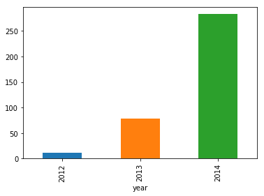

```python
train.groupby('year')['Count'].mean().plot.bar()
```

```python
train.groupby('month')['Count'].mean()
```

```
month
1      92.817204
2     111.196429
3     103.791667
4     137.680556
5     155.055108
6     186.723611
7     209.071237
8     220.497585
9     181.958824
10     75.459677
11     78.413889
12     86.533602
Name: Count, dtype: float64
```

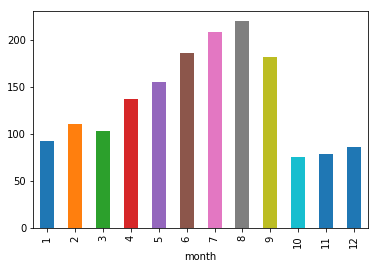

```python
train.groupby('month')['Count'].mean().plot.bar()
```

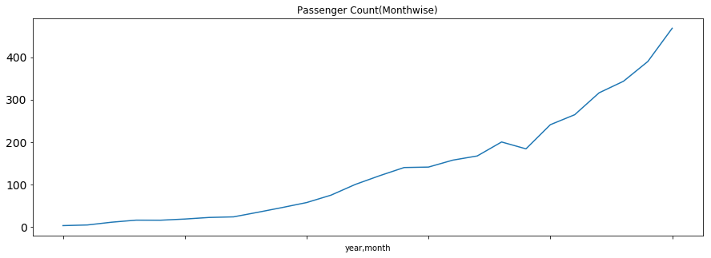

```python
temp=train.groupby(['year', 'month'])['Count'].mean()
temp.plot(figsize=(15,5), title= 'Passenger Count(Monthwise)', fontsize=14)
```

here we ccan see that increasing trend if we combine the year and month !!

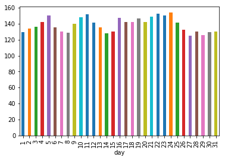

```python
train.groupby('day')['Count'].mean().plot.bar()
```

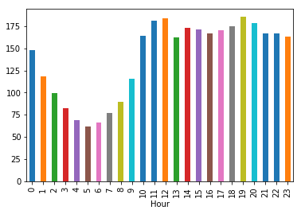

```python
train.groupby('Hour')['Count'].mean().plot.bar()
```

We are not getting much insights from day wise count of the passengers.

We also made a hypothesis that the traffic will be more during peak hours. So let’s see the mean of hourly passenger count.

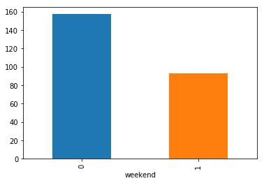

```python
train.groupby('weekend')['Count'].mean().plot.bar()
```

It can be inferred fromabobe barplot that on weekdays traffi count is more than weekends that is saturday and sunday.

now lets examine the trend on the basis of day of week from 0 to 6 here 0 is monday and 6 is sunday !

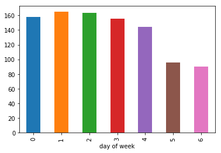

```python
train.groupby('day of week')['Count'].mean().plot.bar()
```

inference achieved is quit happy with our hypothesis made

Dropping unnecessary features which has nothing to do with our outcome \Results

```python
train=train.drop('ID',1)
```

As we have seen that there is a lot of noise in the hourly time series, we will aggregate the hourly time series to daily, weekly, and monthly time series to reduce the noise and make it more stable and hence would be easier for a model to learn.

```python
train.Timestamp = pd.to_datetime(train.Datetime,format='%d-%m-%Y %H:%M')
train.index = train.Timestamp

# Hourly time series
hourly = train.resample('H').mean()

# Converting to daily mean
daily = train.resample('D').mean()

# Converting to weekly mean
weekly = train.resample('W').mean()

# Converting to monthly mean
monthly = train.resample('M').mean()
```

Let’s look at the hourly, daily, weekly and monthly time series.

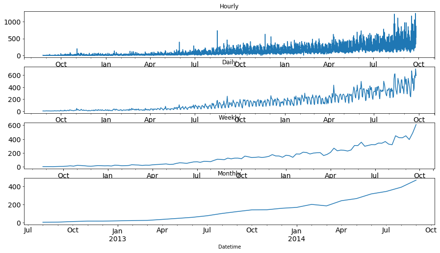

```python
fig, axs = plt.subplots(4,1)

hourly.Count.plot(figsize=(15,8), title= 'Hourly', fontsize=14, ax=axs[0])
daily.Count.plot(figsize=(15,8), title= 'Daily', fontsize=14, ax=axs[1])
weekly.Count.plot(figsize=(15,8), title= 'Weekly', fontsize=14, ax=axs[2])
monthly.Count.plot(figsize=(15,8), title= 'Monthly', fontsize=14, ax=axs[3])

plt.show()
```

We can see that the time series is becoming more and more stable when we are aggregating it on daily, weekly and monthly basis.

But it would be difficult to convert the monthly and weekly predictions to hourly predictions, as first we have to convert the monthly predictions to weekly, weekly to daily and daily to hourly predictions, which will become very expanded process. So, we will work on the daily time series.

```python
test.Timestamp = pd.to_datetime(test.Datetime,format='%d-%m-%Y %H:%M')
test.index = test.Timestamp

# Converting to daily mean
test = test.resample('D').mean()

train.Timestamp = pd.to_datetime(train.Datetime,format='%d-%m-%Y %H:%M')
train.index = train.Timestamp

# Converting to daily mean
train = train.resample('D').mean()
```

```python
train.head()

test.head()
```

| Datetime | ID | year | month | day | Hour |
| --- | --- | --- | --- | --- | --- |
| 2014-09-26 | 18299.5 | 2014.0 | 9.0 | 26.0 | 11.5 |
| 2014-09-27 | 18323.5 | 2014.0 | 9.0 | 27.0 | 11.5 |
| 2014-09-28 | 18347.5 | 2014.0 | 9.0 | 28.0 | 11.5 |
| 2014-09-29 | 18371.5 | 2014.0 | 9.0 | 29.0 | 11.5 |
| 2014-09-30 | 18395.5 | 2014.0 | 9.0 | 30.0 | 11.5 |

```python
from IPython.core.interactiveshell import InteractiveShell
InteractiveShell.ast_node_interactivity = "all"
```

# Splitting the data into training set and validation set

Just to get the accuracy on unseen data we will train our model o training datasets and then go for checking predictuon accuracy !!

To divide the data into training and validation set, we will take last 3 months as the validation data and rest for training data. We will take only 3 months as the trend will be the most in them. If we take more than 3 months for the validation set, our training set will have less data points as the total duration is of 25 months. So, it will be a good choice to take 3 months for validation set.

```python
print('we are taking last three months of data as validation because that can be adequate for checking model accuracy')
```

```
we are taking last three months of data as validation because that can be adequate for checking model accuracy
```

```python
Train=train.ix['2012-08-25':'2014-06-24']
valid=train.ix['2014-06-25':'2014-09-25']
```

We have done time based validation here by selecting the last 3 months for the validation data and rest in the train data. If we would have done it randomly it may work well for the train dataset but will not work effectively on validation dataset.

Lets understand it in this way: If we choose the split randomly it will take some values from the starting and some from the last years as well. It is similar to predicting the old values based on the future values which is not the case in real scenario. So, this kind of split is used while working with time related problems.

```python
train.head()
```

| Datetime | Count | year | month | day | Hour | day of week | weekend |
| --- | --- | --- | --- | --- | --- | --- | --- |
| 2012-08-25 | 3.166667 | 2012.0 | 8.0 | 25.0 | 11.5 | 5.0 | 1.0 |
| 2012-08-26 | 3.666667 | 2012.0 | 8.0 | 26.0 | 11.5 | 6.0 | 1.0 |
| 2012-08-27 | 2.583333 | 2012.0 | 8.0 | 27.0 | 11.5 | 0.0 | 0.0 |
| 2012-08-28 | 2.416667 | 2012.0 | 8.0 | 28.0 | 11.5 | 1.0 | 0.0 |
| 2012-08-29 | 2.500000 | 2012.0 | 8.0 | 29.0 | 11.5 | 2.0 | 0.0 |

```python
valid.head()
```

| Datetime | Count | year | month | day | Hour | day of week | weekend |
| --- | --- | --- | --- | --- | --- | --- | --- |
| 2014-06-25 | 353.666667 | 2014.0 | 6.0 | 25.0 | 11.5 | 2.0 | 0.0 |
| 2014-06-26 | 395.250000 | 2014.0 | 6.0 | 26.0 | 11.5 | 3.0 | 0.0 |
| 2014-06-27 | 282.333333 | 2014.0 | 6.0 | 27.0 | 11.5 | 4.0 | 0.0 |
| 2014-06-28 | 218.250000 | 2014.0 | 6.0 | 28.0 | 11.5 | 5.0 | 1.0 |
| 2014-06-29 | 196.250000 | 2014.0 | 6.0 | 29.0 | 11.5 | 6.0 | 1.0 |

```
Text(0.5,0,'Datetime')
```

```
Text(0,0.5,'Passenger count')
```

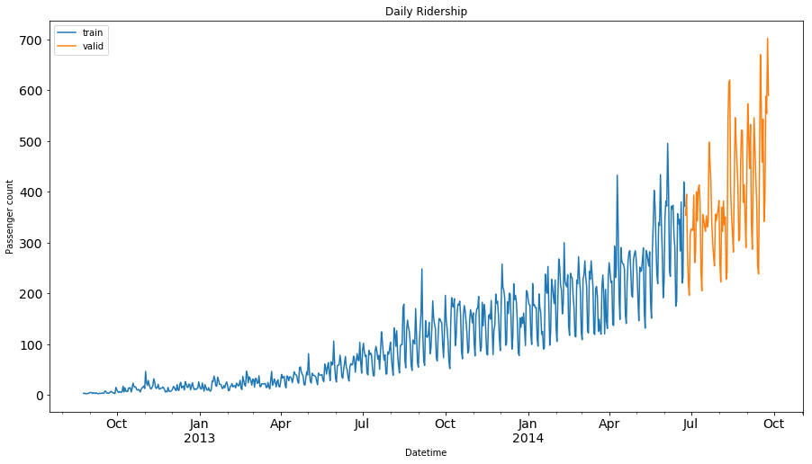

```python
Train.Count.plot(figsize=(15,8), title= 'Daily Ridership', fontsize=14, label='train')
valid.Count.plot(figsize=(15,8), title= 'Daily Ridership', fontsize=14, label='valid')
plt.xlabel("Datetime")
plt.ylabel("Passenger count")
plt.legend(loc='best')
plt.show()
```

# Modelling Time series Technniques

### 1.Naive Method

In this forecasting technique, we assume that the next expected point is equal to the last observed point. So we can expect a straight horizontal line as the prediction. Lets understand it with an example and an image:

```
Text(0.5,1,'Naive Forecast')
```

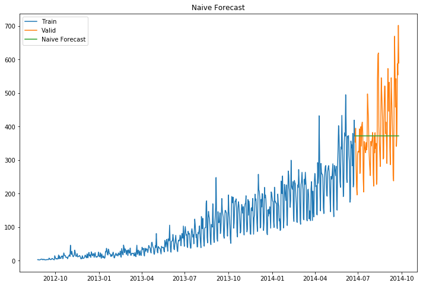

```python
dd= np.asarray(Train.Count)
y_hat = valid.copy()
y_hat['naive'] = dd[len(dd)-1]
plt.figure(figsize=(12,8))
plt.plot(Train.index, Train['Count'], label='Train')
plt.plot(valid.index,valid['Count'], label='Valid')
plt.plot(y_hat.index,y_hat['naive'], label='Naive Forecast')
plt.legend(loc='best')
plt.title("Naive Forecast")
plt.show()
```

```python
from sklearn.metrics import mean_squared_error
from math import sqrt
rms = sqrt(mean_squared_error(valid.Count, y_hat.naive))
print(rms)
```

```
111.79050467496724
```

```python
print('RMSE value can be dropped down using different strategy ,this methodology can be suited for datsets with huge magnitude')
```

```
RMSE value can be dropped down using different strategy ,this methodology can be suited for datsets with huge magnitude
```

## Method of mOVING averages

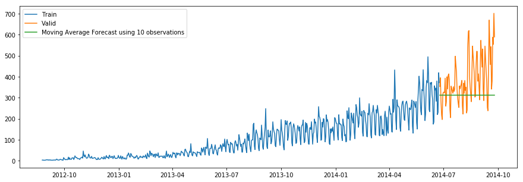

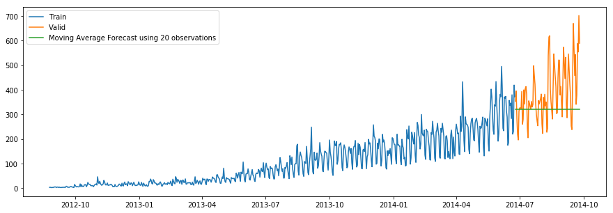

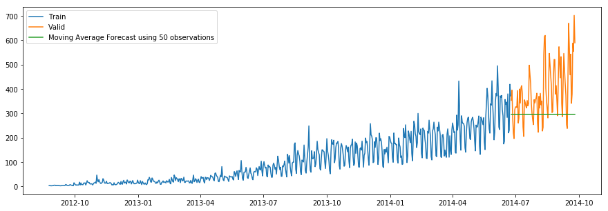

```python
y_hat_avg = valid.copy()
y_hat_avg['moving_avg_forecast'] = Train['Count'].rolling(10).mean().iloc[-1] # average of last 10 observations.
plt.figure(figsize=(15,5))
plt.plot(Train['Count'], label='Train')
plt.plot(valid['Count'], label='Valid')
plt.plot(y_hat_avg['moving_avg_forecast'], label='Moving Average Forecast using 10 observations')
plt.legend(loc='best')
plt.show()
y_hat_avg = valid.copy()
y_hat_avg['moving_avg_forecast'] = Train['Count'].rolling(20).mean().iloc[-1] # average of last 20 observations.
plt.figure(figsize=(15,5))
plt.plot(Train['Count'], label='Train')
plt.plot(valid['Count'], label='Valid')
plt.plot(y_hat_avg['moving_avg_forecast'], label='Moving Average Forecast using 20 observations')
plt.legend(loc='best')
plt.show()
y_hat_avg = valid.copy()
y_hat_avg['moving_avg_forecast'] = Train['Count'].rolling(50).mean().iloc[-1] # average of last 50 observations.
plt.figure(figsize=(15,5))
plt.plot(Train['Count'], label='Train')
plt.plot(valid['Count'], label='Valid')
plt.plot(y_hat_avg['moving_avg_forecast'], label='Moving Average Forecast using 50 observations')
plt.legend(loc='best')
plt.show()
```

```python
rms = sqrt(mean_squared_error(valid.Count, y_hat_avg.moving_avg_forecast))
print(rms)
```

```
144.19175679986802
```

# Simple Exponential Smoothing

In this technique, we assign larger weights to more recent observations than to observations from the distant past. The weights decrease exponentially as observations come from further in the past, the smallest weights are associated with the oldest observations. NOTE - If we give the entire weight to the last observed value only, this method will be similar to the naive approach. So, we can say that naive approach is also a simple exponential smoothing technique where the entire weight is given to the last observed value.

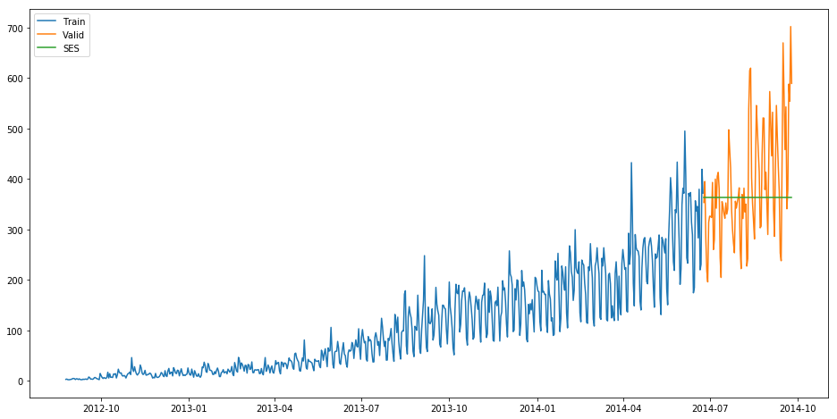

```python
from statsmodels.tsa.api import ExponentialSmoothing, SimpleExpSmoothing, Holt #remember this
y_hat_avg = valid.copy()
fit2 = SimpleExpSmoothing(np.asarray(Train['Count'])).fit(smoothing_level=0.6,optimized=False)
y_hat_avg['SES'] = fit2.forecast(len(valid))
plt.figure(figsize=(16,8))
plt.plot(Train['Count'], label='Train')
plt.plot(valid['Count'], label='Valid')
plt.plot(y_hat_avg['SES'], label='SES')
plt.legend(loc='best')
plt.show()
```

```python
rms = sqrt(mean_squared_error(valid.Count, y_hat_avg.SES))
print(rms)
```

```
113.43708111884514
```

rmse value is dropped down with exponential smoothing technique !

# Holt's Linear Trend Model

It is an extension of simple exponential smoothing to allow forecasting of data with a trend. This method takes into account the trend of the dataset. The forecast function in this method is a function of level and trend. First of all let us visualize the trend, seasonality and error in the series.

We can decompose the time series in four parts.

Observed, which is the original time series. Trend, which shows the trend in the time series, i.e., increasing or decreasing behaviour of the time series. Seasonal, which tells us about the seasonality in the time series. Residual, which is obtained by removing any trend or seasonality in the time series.

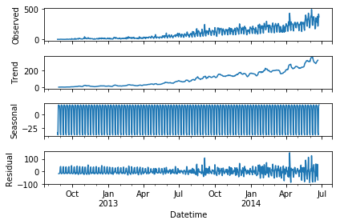

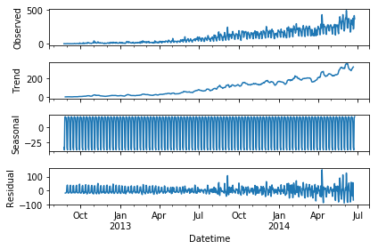

```python
import statsmodels.api as sm
sm.tsa.seasonal_decompose(Train.Count).plot()
result = sm.tsa.stattools.adfuller(train.Count)
plt.show()
```

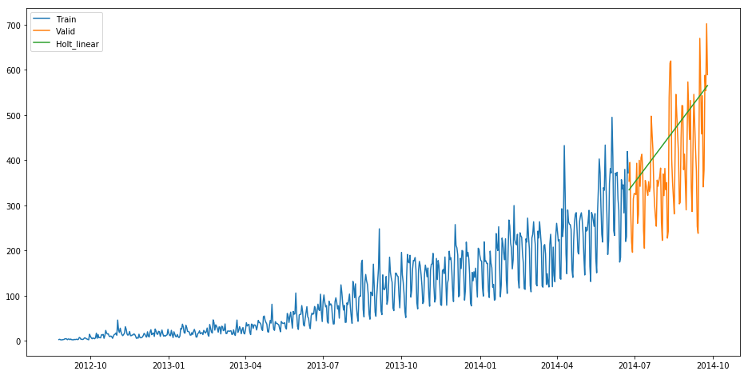

```python
y_hat_avg = valid.copy()

fit1 = Holt(np.asarray(Train['Count'])).fit(smoothing_level = 0.3,smoothing_slope = 0.1)
y_hat_avg['Holt_linear'] = fit1.forecast(len(valid))

plt.figure(figsize=(16,8))
plt.plot(Train['Count'], label='Train')
plt.plot(valid['Count'], label='Valid')
plt.plot(y_hat_avg['Holt_linear'], label='Holt_linear')
plt.legend(loc='best')
plt.show()
```

```python
rms = sqrt(mean_squared_error(valid.Count, y_hat_avg.Holt_linear))
print(rms)
```

```
112.94278345314041
```

It can be inferred that the rmse value has decreased.

Now we will be predicting the passenger count for the test dataset using various models

# Holt's Winter Model on Daily Time SERIES

Considering trends and seasonality both by Holts Winter Model

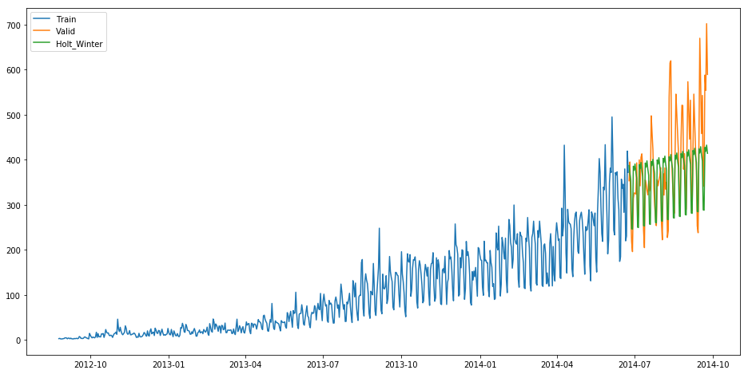

```python
y_hat_avg = valid.copy()
fit1 = ExponentialSmoothing(np.asarray(Train['Count']) ,seasonal_periods=7 ,trend='add', seasonal='add',).fit()
y_hat_avg['Holt_Winter'] = fit1.forecast(len(valid))
plt.figure(figsize=(16,8))
plt.plot( Train['Count'], label='Train')
plt.plot(valid['Count'], label='Valid')
plt.plot(y_hat_avg['Holt_Winter'], label='Holt_Winter')
plt.legend(loc='best')
plt.show()
```

```python
rms = sqrt(mean_squared_error(valid.Count, y_hat_avg.Holt_Winter))
print(rms)
```

```
82.37467736825413
```

We can see that the rmse value has reduced a lot from this method. Let’s forecast the Counts for the entire length of the Test dataset.

```python
predict=fit1.forecast(len(test))
```

```python
test['prediction']=predict
```

```python
test['prediction']
```

```
Datetime
2014-09-26    387.359889
2014-09-27    369.136159
2014-09-28    355.562755
2014-09-29    247.090305
2014-09-30    246.193987
2014-10-01    385.878962
2014-10-02    376.802422
2014-10-03    390.854125
2014-10-04    372.630395
2014-10-05    359.056991
2014-10-06    250.584541
2014-10-07    249.688223
2014-10-08    389.373198
2014-10-09    380.296658
2014-10-10    394.348360
2014-10-11    376.124631
2014-10-12    362.551227
2014-10-13    254.078777
2014-10-14    253.182459
2014-10-15    392.867434
2014-10-16    383.790894
2014-10-17    397.842596
2014-10-18    379.618867
2014-10-19    366.045463
2014-10-20    257.573013
2014-10-21    256.676695
2014-10-22    396.361669
2014-10-23    387.285130
2014-10-24    401.336832
2014-10-25    383.113103
                 ...
2015-03-28    459.986293
2015-03-29    446.412889
2015-03-30    337.940439
2015-03-31    337.044121
2015-04-01    476.729095
2015-04-02    467.652556
2015-04-03    481.704258
2015-04-04    463.480528
```

[output cut: 8 more lines]

```
2015-04-13    344.928911
2015-04-14    344.032592
2015-04-15    483.717567
2015-04-16    474.641027
2015-04-17    488.692730
2015-04-18    470.469000
2015-04-19    456.895597
2015-04-20    348.423147
2015-04-21    347.526828
2015-04-22    487.211803
2015-04-23    478.135263
2015-04-24    492.186966
2015-04-25    473.963236
2015-04-26    460.389832
Freq: D, Name: prediction, Length: 213, dtype: float64
```

# ARIMA Modelling

### Stationarity

What is a stationary time series? There are three basic criterion for a series to be classified as stationary series :

The mean of the time series should not be a function of time. It should be constant. The variance of the time series should not be a function of time. THe covariance of the ith term and the (i+m)th term should not be a function of time. Why do we have to make the time series stationary? We make the series stationary to make the variables independent. Variables can be dependent in various ways, but can only be independent in one way. So, we will get more information when they are independent. Hence the time series must be stationary.

```python
from statsmodels.tsa.stattools import adfuller
def test_stationarity(timeseries):

    #Determing rolling statistics
    rolmean = timeseries.rolling(window=24) # 24 hours on each day
    rolstd =  timeseries.rolling(window=24)

    #Plot rolling statistics:
    orig = plt.plot(timeseries, color='blue',label='Original')
    mean = plt.plot(rolmean, color='red', label='Rolling Mean')
    std = plt.plot(rolstd, color='black', label = 'Rolling Std')
    plt.legend(loc='best')
    plt.title('Rolling Mean & Standard Deviation')
    plt.show(block=False)

    #Perform Dickey-Fuller test:
    print ('Results of Dickey-Fuller Test:')
    dftest = adfuller(timeseries, autolag='AIC')
    dfoutput = pd.Series(dftest[0:4], index=['Test Statistic','p-value','#Lags Used','Number of Observations Used'])
    for key,value in dftest[4].items():
        dfoutput['Critical Value (%s)'%key] = value
    print (dfoutput)
```

```python
from matplotlib.pylab import rcParams
rcParams['figure.figsize'] = 20,10
```

[output not shown]

[output cut: 45 more lines]

[output not shown]

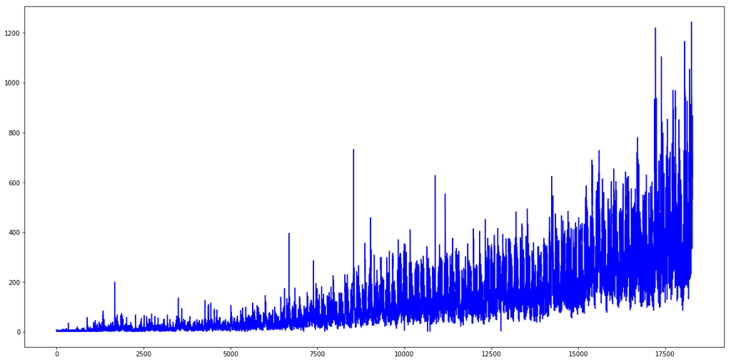

```python
test_stationarity(train_original['Count'])
```

```python
print('Dickey Fuller Test to test Stationary of timeseries')
```

```
Dickey Fuller Test to test Stationary of timeseries
```

```python
timeseries=train_original['Count']
```

```python
print ('Results of Dickey-Fuller Test:')
dftest = adfuller(timeseries, autolag='AIC')
dfoutput = pd.Series(dftest[0:4], index=['Test Statistic','p-value','#Lags Used','Number of Observations Used'])
for key,value in dftest[4].items():
        dfoutput['Critical Value (%s)'%key] = value
print (dfoutput)
```

```
Results of Dickey-Fuller Test:
Test Statistic                    -4.456561
p-value                            0.000235
#Lags Used                        45.000000
Number of Observations Used    18242.000000
Critical Value (1%)               -3.430709
Critical Value (5%)               -2.861698
Critical Value (10%)              -2.566854
dtype: float64
```

Removing Trend A trend exists when there is a long-term increase or decrease in the data. It does not have to be linear.

We see an increasing trend in the data so we can apply transformation which penalizes higher values more than smaller ones, for example log transformation.

```python
Train_log = np.log(Train['Count'])
valid_log = np.log(valid['Count'])
```

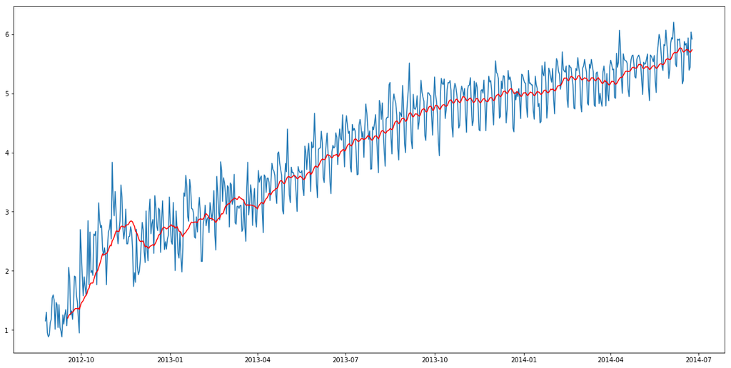

```python
moving_avg = Train_log.rolling(24).mean()
plt.plot(Train_log)
plt.plot(moving_avg, color = 'red')
plt.show()
```

```python
train_log_moving_avg_diff = Train_log - moving_avg
train_log_moving_avg_diff.tail()
```

```
Datetime
2014-06-20    0.200295
2014-06-21   -0.317381
2014-06-22   -0.253342
2014-06-23    0.326990
2014-06-24    0.179745
Freq: D, Name: Count, dtype: float64
```

[output not shown]

[output cut: 46 more lines]

[output not shown]

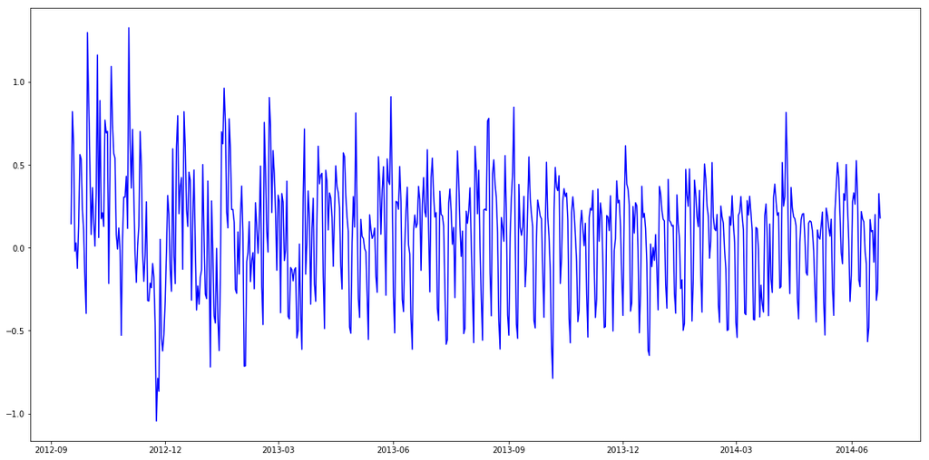

```python
train_log_moving_avg_diff.dropna(inplace = True)
test_stationarity(train_log_moving_avg_diff)
```

[output not shown]

[output cut: 46 more lines]

[output not shown]

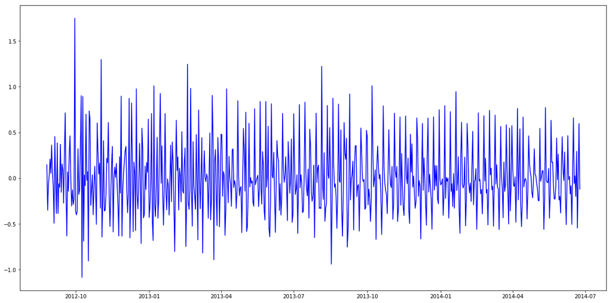

```python
train_log_diff = Train_log - Train_log.shift(1)
test_stationarity(train_log_diff.dropna())
```

```python
print ('Results of Dickey-Fuller Test:')
dftest = adfuller(train_log_moving_avg_diff, autolag='AIC')
dfoutput = pd.Series(dftest[0:4], index=['Test Statistic','p-value','#Lags Used','Number of Observations Used'])
for key,value in dftest[4].items():
        dfoutput['Critical Value (%s)'%key] = value
print (dfoutput)
```

```
Results of Dickey-Fuller Test:
Test Statistic                -5.861646e+00
p-value                        3.399422e-07
#Lags Used                     2.000000e+01
Number of Observations Used    6.250000e+02
Critical Value (1%)           -3.440856e+00
Critical Value (5%)           -2.866175e+00
Critical Value (10%)          -2.569239e+00
dtype: float64
```

Removing Seasonality By seasonality, we mean periodic fluctuations. A seasonal pattern exists when a series is influenced by seasonal factors (e.g., the quarter of the year, the month, or day of the week). Seasonality is always of a fixed and known period. We will use seasonal decompose to decompose the time series into trend, seasonality and residuals.

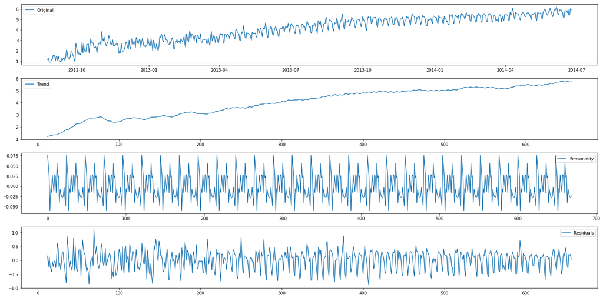

```python
from statsmodels.tsa.seasonal import seasonal_decompose
decomposition = seasonal_decompose(pd.DataFrame(Train_log).Count.values, freq = 24)

trend = decomposition.trend
seasonal = decomposition.seasonal
residual = decomposition.resid

plt.subplot(411)
plt.plot(Train_log, label='Original')
plt.legend(loc='best')
plt.subplot(412)
plt.plot(trend, label='Trend')
plt.legend(loc='best')
plt.subplot(413)
plt.plot(seasonal,label='Seasonality')
plt.legend(loc='best')
plt.subplot(414)
plt.plot(residual, label='Residuals')
plt.legend(loc='best')
plt.tight_layout()
plt.show()
```

[output not shown]

[output cut: 47 more lines]

[output not shown]

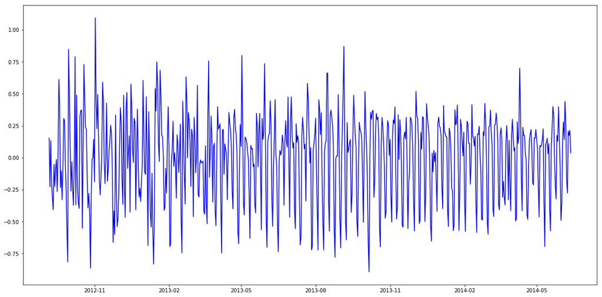

```python
train_log_decompose = pd.DataFrame(residual)
train_log_decompose['date'] = Train_log.index
train_log_decompose.set_index('date', inplace = True)
train_log_decompose.dropna(inplace=True)
test_stationarity(train_log_decompose[0])
```

```python
print ('Results of Dickey-Fuller Test:')
dftest = adfuller(train_log_decompose[0], autolag='AIC')
dfoutput = pd.Series(dftest[0:4], index=['Test Statistic','p-value','#Lags Used','Number of Observations Used'])
for key,value in dftest[4].items():
        dfoutput['Critical Value (%s)'%key] = value
print (dfoutput)
```

```
Results of Dickey-Fuller Test:
Test Statistic                -7.822096e+00
p-value                        6.628321e-12
#Lags Used                     2.000000e+01
Number of Observations Used    6.240000e+02
Critical Value (1%)           -3.440873e+00
Critical Value (5%)           -2.866183e+00
Critical Value (10%)          -2.569243e+00
dtype: float64
```

It can be interpreted from the results that the residuals are stationary.

Now we will forecast the time series using different models.

Forecasting the time series using ARIMA First of all we will fit the ARIMA model on our time series for that we have to find the optimized values for the p,d,q parameters.

To find the optimized values of these parameters, we will use ACF(Autocorrelation Function) and PACF(Partial Autocorrelation Function) graph.

ACF is a measure of the correlation between the TimeSeries with a lagged version of itself.

PACF measures the correlation between the TimeSeries with a lagged version of itself but after eliminating the variations already explained by the intervening comparisons.

## ACF and PACF : Paremeter tuning

```python
from statsmodels.tsa.stattools import acf, pacf
lag_acf = acf(train_log_diff.dropna(), nlags=25)
lag_pacf = pacf(train_log_diff.dropna(), nlags=25, method='ols')
```

```
Text(0.5,1,'Autocorrelation Function')
```

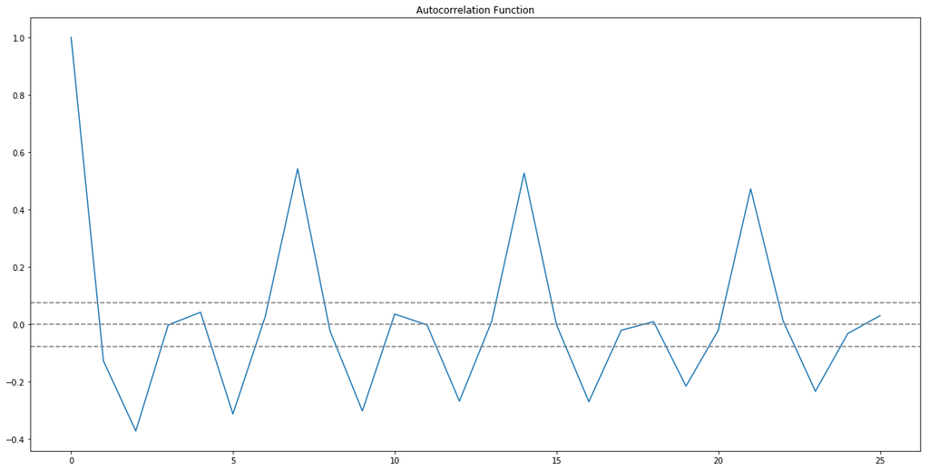

```
Text(0.5,1,'Partial Autocorrelation Function')
```

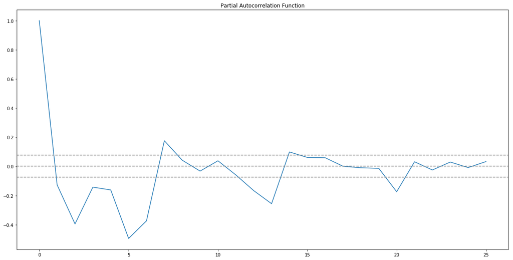

```python
plt.plot(lag_acf)
plt.axhline(y=0,linestyle='--',color='gray')
plt.axhline(y=-1.96/np.sqrt(len(train_log_diff.dropna())),linestyle='--',color='gray')
plt.axhline(y=1.96/np.sqrt(len(train_log_diff.dropna())),linestyle='--',color='gray')
plt.title('Autocorrelation Function')
plt.show()
plt.plot(lag_pacf)
plt.axhline(y=0,linestyle='--',color='gray')
plt.axhline(y=-1.96/np.sqrt(len(train_log_diff.dropna())),linestyle='--',color='gray')
plt.axhline(y=1.96/np.sqrt(len(train_log_diff.dropna())),linestyle='--',color='gray')
plt.title('Partial Autocorrelation Function')
plt.show()
```

## AR model

```python
from statsmodels.tsa.arima_model import ARIMA
```

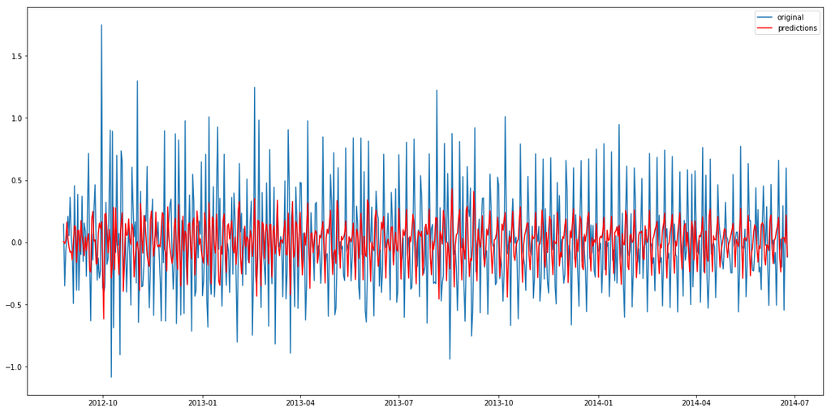

```python
model = ARIMA(Train_log, order=(2, 1, 0))  # here the q value is zero since it is just the AR model
results_AR = model.fit(disp=-1)
plt.plot(train_log_diff.dropna(), label='original')
plt.plot(results_AR.fittedvalues, color='red', label='predictions')
plt.legend(loc='best')
plt.show()
```

```python
AR_predict=results_AR.predict(start="2014-06-25", end="2014-09-25")
AR_predict=AR_predict.cumsum().shift().fillna(0)
AR_predict1=pd.Series(np.ones(valid.shape[0]) * np.log(valid['Count'])[0], index = valid.index)
AR_predict1=AR_predict1.add(AR_predict,fill_value=0)
AR_predict = np.exp(AR_predict1)
```

```
Text(0.5,1,'RMSE: 43.9740')
```

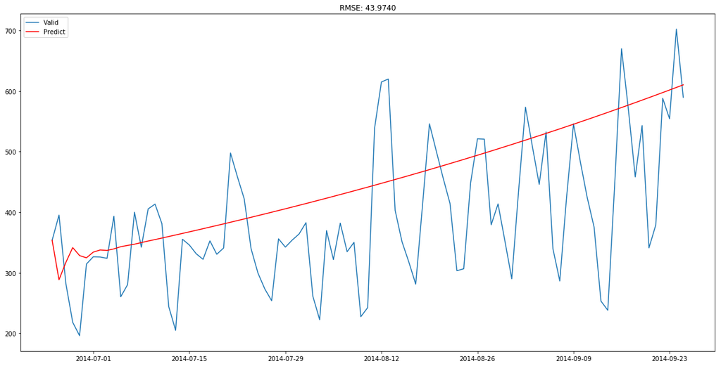

```python
plt.plot(valid['Count'], label = "Valid")
plt.plot(AR_predict, color = 'red', label = "Predict")
plt.legend(loc= 'best')
plt.title('RMSE: %.4f'% (np.sqrt(np.dot(AR_predict, valid['Count']))/valid.shape[0]))
plt.show()
```